# itscausal — User Manual

Causal estimation for interrupted time series using machine learning

Author

Aurelien Sallin

Published

February 24, 2026

## Overview

`itscausal` estimates the causal effect of a policy intervention applied to a panel of units observed over time — an **interrupted time series (ITS)** design.

The key idea: train ML models on the **pre-intervention** window to predict what each unit’s outcome would have looked like *without* the intervention. The individual treatment effect (ITE) is the difference between observed and predicted (counterfactual) outcomes.

The workflow is:

1. **Simulate / load** a panel dataset in long format
2. **`forecastITS()`** — sliding-window cross-validated forecast of the counterfactual
3. **`iteITS()`** — compute per-unit, per-period treatment effects
4. **`ateITS()`** — aggregate to average treatment effects (ATE)

## Setup

```r
devtools::load_all(quiet = TRUE)   # load package from source (no build needed)
library(data.table)
library(ggplot2)

set.seed(20240101)
```

## 1. Simulate data

```r
# --- Parameters ---
n_id          <- 60
n_time        <- 72
INDEX         <- 60L          # intervention at month 60
true_effect   <- -3           # level shift

# --- Helper: AR(1) process ---
ar1 <- function(n, phi = 0.6, sigma = 1) {
  e <- rnorm(n, 0, sigma)
  x <- numeric(n)
  x[1] <- e[1]
  for (t in 2:n) x[t] <- phi * x[t - 1] + e[t]
  x
}

# --- Individual-level draws ---
X        <- sample(c(0, 1), n_id, replace = TRUE)   # binary group
id_fx    <- rnorm(n_id, 0, 3)                        # individual fixed effect

# --- Panel skeleton ---
df <- data.table(
  ID     = rep(seq_len(n_id), each = n_time),
  time   = rep(seq_len(n_time), n_id),
  X      = rep(X, each = n_time),
  id_fx  = rep(id_fx, each = n_time)
)

# --- Seasonal pattern (monthly, period = 12) ---
season_coefs <- c(0, 1.5, 2.8, 3.1, 2.4, 1.2, -0.5, -1.8, -2.1, -1.4, 0, 0.3)
df[, month  := ((time - 1) %% 12) + 1]
df[, year   := ((time - 1) %/% 12) + 1]
df[, season := season_coefs[month]]

# --- AR(1) errors (individual-specific) ---
df[, error := unlist(replicate(n_id, ar1(n_time, phi = 0.5, sigma = 1.5),
                               simplify = FALSE))]

# --- Outcome ---
df[, post := as.integer(time >= INDEX)]
df[, y := 2 + 0.05 * time          # trend
        + 0.8 * X                   # group effect
        + season                    # seasonality
        + id_fx                     # fixed effect
        + true_effect * post        # treatment
        + error]                    # noise

# Centre time on the intervention (convention: pre = negative, post = positive)
df[, time_c := time - INDEX]

cat("Panel dimensions:", n_id, "units ×", n_time, "periods =", nrow(df), "rows\n")
```

```
Panel dimensions: 60 units × 72 periods = 4320 rows
```

```r
cat("Pre-intervention periods: ", sum(df$time_c < 0) / n_id, "\n")
```

```
Pre-intervention periods:  59
```

```r
cat("Post-intervention periods:", sum(df$time_c >= 0) / n_id, "\n")
```

```
Post-intervention periods: 13
```

### Raw data plot

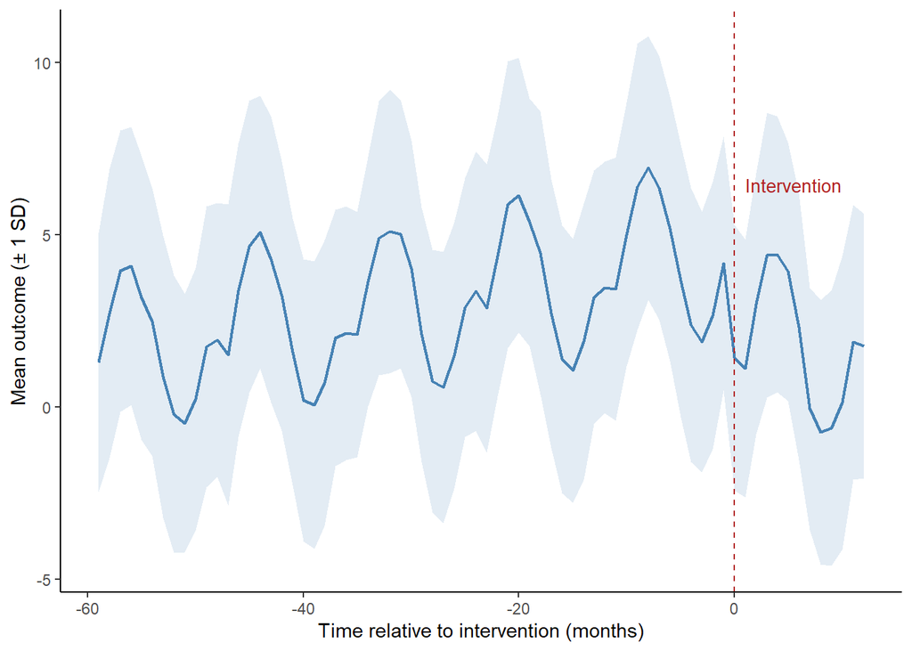

Figure 1: Average outcome over time (group mean ± 1 SD). The dashed line marks the intervention.

```r
avg <- df[, .(mean_y = mean(y), sd_y = sd(y)), by = .(time, time_c)]

ggplot(avg, aes(x = time_c, y = mean_y)) +
  geom_ribbon(aes(ymin = mean_y - sd_y, ymax = mean_y + sd_y),
              alpha = 0.15, fill = "steelblue") +
  geom_line(colour = "steelblue", linewidth = 0.8) +
  geom_vline(xintercept = 0, linetype = "dashed", colour = "firebrick") +
  annotate("text", x = 1, y = max(avg$mean_y) - 0.5,
           label = "Intervention", hjust = 0, colour = "firebrick", size = 3.5) +
  labs(x = "Time relative to intervention (months)",
       y = "Mean outcome (± 1 SD)") +
  theme_classic()
```

## 2. Forecast the counterfactual with `forecastITS()`

`forecastITS()` is the main function. It:

1. Reshapes the panel into a wide “lag” matrix (via `flattenDataITS`)
2. Splits units into K cross-validation folds (via `crossValidateITS`)
3. Trains the ensemble of ML models on each fold
4. Uses multi-step-ahead forecasting to project the counterfactual

Key arguments:

| Argument | Meaning |
| --- | --- |
| `data` | Long-format panel (data.frame or data.table) |
| `time` | Name of the time variable |
| `key` | Name of the unit identifier |
| `y` | Name of the outcome |
| `INDEX` | Time period of the intervention |
| `WINDOW` | Number of lags used as features |
| `STEPS` | Pre-intervention periods held out for CV error assessment |
| `covariates_time` | Time-varying covariates used as features (e.g. month, year) |
| `covariates_fix` | Time-invariant unit covariates (e.g. group) |
| `method` | Models to include: `"lm"`, `"rf"`, `"xgboost"` |
| `K` | Number of cross-validation folds |

```r
fore <- forecastITS(
  data             = df,
  time             = "time",
  key              = "ID",
  y                = "y",
  INDEX            = INDEX,
  WINDOW           = 24L,          # 2-year lag window
  STEPS            = 6L,           # hold out 6 pre-periods for CV
  covariates_time  = c("month", "year"),
  covariates_fix   = c("X"),
  method           = c("lm", "xgboost"),
  K                = 5L
)
```

### Ensemble weights

The models are blended using inverse-RMSE weights estimated on the held-out pre-intervention periods:

```r
round(fore$RMSEweights, 3)
```

```
     lm xgboost
   0.92    0.08
```

### Predicted vs observed (population average)

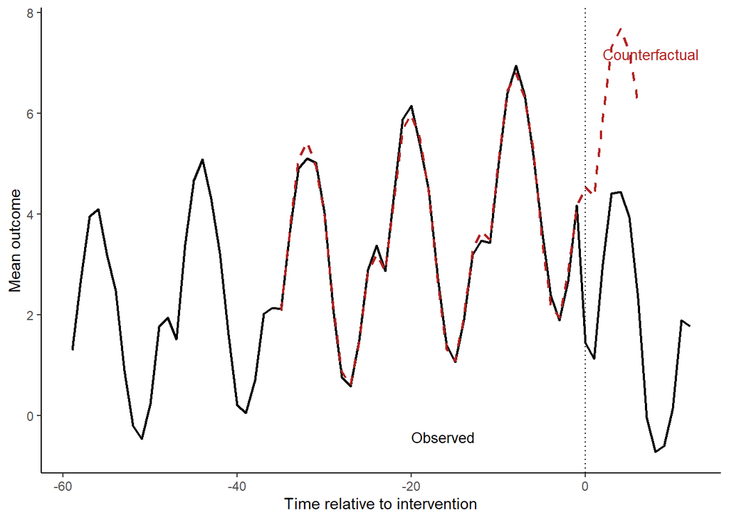

Figure 2: Population average: observed outcome (black) vs ML counterfactual forecast (red). Post-intervention gap is the estimated treatment effect.

```r
# Merge forecasts with original data
dfOut <- fore$out                           # columns: ID, time, y_hat
setDT(dfOut)
setnames(dfOut, "time", "time_c")           # time was centred by forecastITS

dfMerge <- merge(df[, .(ID, time_c, y)],
                 dfOut[, .(ID, time_c, y_hat)],
                 by = c("ID", "time_c"), all.x = TRUE)

# Population average
avg2 <- dfMerge[, .(y = mean(y), y_hat = mean(y_hat, na.rm = TRUE)), by = time_c]

ggplot(avg2, aes(x = time_c)) +
  geom_line(aes(y = y), colour = "black", linewidth = 0.8) +
  geom_line(aes(y = y_hat), colour = "firebrick", linewidth = 0.8,
            linetype = "dashed") +
  geom_vline(xintercept = 0, linetype = "dotted") +
  scale_colour_manual(values = c("Observed" = "black", "Counterfactual" = "firebrick")) +
  labs(x = "Time relative to intervention",
       y = "Mean outcome",
       colour = NULL) +
  annotate("text", x = -20, y = min(avg2$y, na.rm = TRUE) + 0.3,
           label = "Observed", hjust = 0, size = 3.5) +
  annotate("text", x = 2, y = max(avg2$y_hat, na.rm = TRUE) - 0.5,
           label = "Counterfactual", colour = "firebrick", hjust = 0, size = 3.5) +
  theme_classic()
```

## 3. Individual treatment effects with `iteITS()`

`iteITS()` computes the **individual treatment effect** (ITE) for each unit and each post-intervention period:

$$\text{ITE}_{it} = \hat{y}_{it}^{(0)} - y_{it}, \quad t > 0$$

where $\hat{y}^{(0)}$ is the counterfactual prediction.

```r
iteM <- iteITS(forecast.object = fore)
head(iteM$ites)
```

```
    time     X      ite       sd
   <num> <num>    <num>    <num>
1:     1     0 3.530803 1.871023
2:     2     0 3.396366 1.525604
3:     3     0 3.370242 1.713500
4:     4     0 3.624375 1.324585
5:     5     0 3.547280 1.754714
6:     6     0 4.084766 1.286145
```

### ITE over time

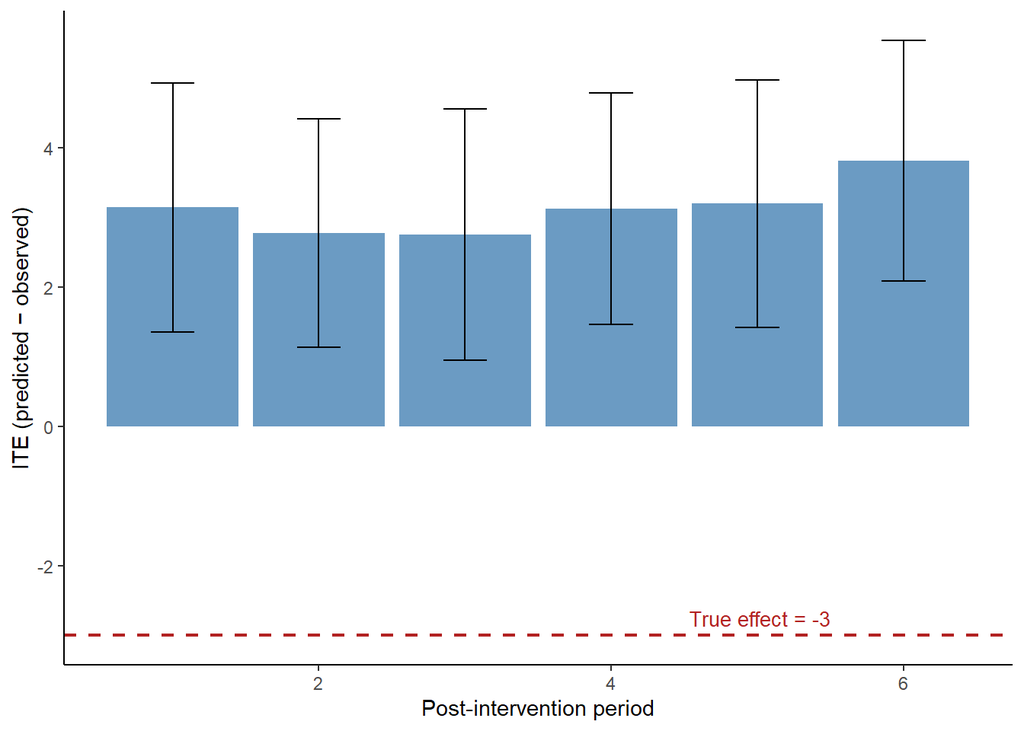

Figure 3: Mean ITE per post-intervention period (bar) ± 1 SD (error bar). The true effect is −3.

```r
# iteM$ites is grouped by (time, X); aggregate to population average for plotting
ite_pop <- as.data.frame(iteM$ites)[, c("time", "ite", "sd")]
ite_pop <- aggregate(cbind(ite, sd) ~ time, data = ite_pop, FUN = mean)

ggplot(ite_pop, aes(x = time, y = ite)) +
  geom_col(fill = "steelblue", alpha = 0.8) +
  geom_errorbar(aes(ymin = ite - sd, ymax = ite + sd), width = 0.3) +
  geom_hline(yintercept = true_effect, linetype = "dashed",
             colour = "firebrick", linewidth = 0.8) +
  annotate("text", x = max(ite_pop$time) - 0.5, y = true_effect + 0.25,
           label = paste("True effect =", true_effect),
           colour = "firebrick", hjust = 1, size = 3.5) +
  labs(x = "Post-intervention period",
       y = "ITE (predicted − observed)") +
  theme_classic()
```

## 4. Average treatment effects with `ateITS()`

`ateITS()` aggregates ITEs into summary treatment effects:

- **InstATE** — per-period average across units (time series of ATEs)
- **TATE** — time-averaged ATE over the first `n.periods` post-intervention periods

### Instantaneous ATE

```r
ate_all <- ateITS(forecast.object = fore, ite.object = iteM)
ate_all$InstATE$pred
```

```
    time      ite
   <num>    <num>
1:     1 3.143651
2:     2 2.778808
3:     3 2.754151
4:     4 3.123708
5:     5 3.196602
6:     6 3.811447
```

### Time-averaged ATE (all post-intervention periods)

```r
n_post <- max(iteM$ites$time)
ate_total <- ateITS(fore, iteM, n.periods = n_post)

cat(sprintf(
  "TATE over %d periods:  %.3f  (SD = %.3f)\nTrue effect: %.1f\n",
  n_post,
  ate_total$TATE$pred$ite,
  ate_total$TATE$sd$sd,
  true_effect
))
```

```
TATE over 6 periods:  3.135  (SD = 0.617)
True effect: -3.0
```

### TATE for early vs later periods

```r
ate_early <- ateITS(fore, iteM, n.periods = 3)
ate_late  <- ateITS(fore, iteM, n.periods = n_post)

results <- data.frame(
  Period    = c("First 3 months", paste("All", n_post, "months")),
  TATE      = c(ate_early$TATE$pred$ite, ate_late$TATE$pred$ite),
  SD        = c(ate_early$TATE$sd$sd,    ate_late$TATE$sd$sd)
)
results$lower <- results$TATE - 1.96 * results$SD
results$upper <- results$TATE + 1.96 * results$SD
results
```

```
          Period     TATE        SD    lower    upper
1 First 3 months 2.892203 0.6343428 1.648891 4.135515
2   All 6 months 3.134728 0.6168360 1.925729 4.343726
```

## 5. Heterogeneous effects by group

Pass a `groups` argument to `ateITS()` to compute group-specific ATEs. Here we split by the binary covariate `X`. Because `X` must appear in the ITE table, it needs to be listed in `covariates_fix` when running `forecastITS()` (which we did above).

```r
ate_bygroup <- ateITS(fore, iteM, n.periods = n_post, groups = "X")

ate_bygroup$TATE$pred
```

```
       X      ite
   <num>    <num>
1:     0 3.592305
2:     1 2.677150
```

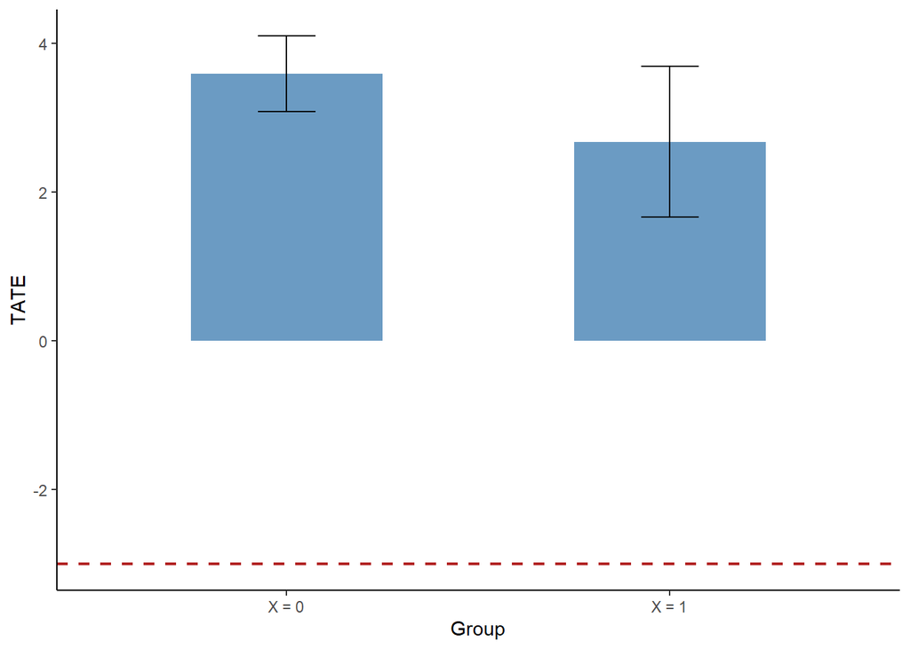

Figure 4: TATE by group (X = 0 vs X = 1) with 95% confidence interval. True effect is the same for both groups (−3).

```r
gate_df <- cbind(ate_bygroup$TATE$pred, SD = ate_bygroup$TATE$sd$sd)
gate_df$lower <- gate_df$ite - 1.96 * gate_df$SD
gate_df$upper <- gate_df$ite + 1.96 * gate_df$SD
gate_df$X <- factor(gate_df$X, labels = c("X = 0", "X = 1"))

ggplot(gate_df, aes(x = X, y = ite)) +
  geom_col(fill = "steelblue", alpha = 0.8, width = 0.5) +
  geom_errorbar(aes(ymin = lower, ymax = upper), width = 0.15) +
  geom_hline(yintercept = true_effect, linetype = "dashed",
             colour = "firebrick", linewidth = 0.8) +
  labs(x = "Group", y = "TATE") +
  theme_classic()
```

## 6. Parameter guide

### Choosing `WINDOW`

`WINDOW` is the number of lagged outcome values used as features. A window that spans one full seasonal cycle is a good default (e.g. `WINDOW = 12` for monthly data). Larger windows capture more history but reduce the number of training observations.

### Choosing `STEPS`

`STEPS` is the number of pre-intervention periods held out for cross-validation error assessment. These periods are *not* used for training. Values between 3 and 12 are typical; at least one full seasonal cycle is recommended.

**Constraint:** `WINDOW + STEPS` must be strictly less than the total number of pre-intervention periods.

### Choosing `method`

| Method | Notes |
| --- | --- |
| `"lm"` | Fast, interpretable; handles seasonality well when year/month dummies are included |
| `"rf"` | Captures non-linearities; slower; good default for complex DGPs |
| `"xgboost"` | Gradient boosting; often the strongest single learner |

Using all three (`method = c("lm", "rf", "xgboost")`) invokes the **ensemble learner**, which blends predictions by inverse-RMSE weights.